# Time Series Modeling Training

Samuel Gonzalez

December 4, 2017

**Not to be distributed**

# Background

Time Series models are built when data is serially correlated. That is, when the current point has some relationship to the past point, or the past few points. A seasonal correlations my also be observed in time series data.

The next predicted point can be expressed in terms of an estimation of coefficients*lag terms of the time series.

# Motivation

Time Series models allow you to forecast the next point or series of points building upon the historical trend of the data. This is useful in retail, social experiments, stocks (sometimes), energy field. In this case we are modeling a forecast of power generation.

# Stationareity

Time Series models should ONLY be build on stationary data. This process is demonstrated on this training

# ARIMA Models

- Predictive power from an Auto Regressive Component (AR)
  - Term Observed in the PACF
- Predictive power from a Moving Average Component (MA)
  - Term Observed in the ACF
- Integration Term
  - Differencing the data to achieve stationareity

# Validation

- All models used should be valid
  - Box-LJung Test
  - White Noise Test
- Parsimony
  - It is preferrable that all estimates are significant
- Invertibility
  - Does not invalidate the model but care should be taken

```r
summary(df$Power)
```

```
##    Min. 1st Qu.  Median    Mean 3rd Qu.    Max.
##   23605   25207   25324   25210   25471   25481
```

```r
# Create a TimeSeries object

power_ts = ts(df$Power)
```

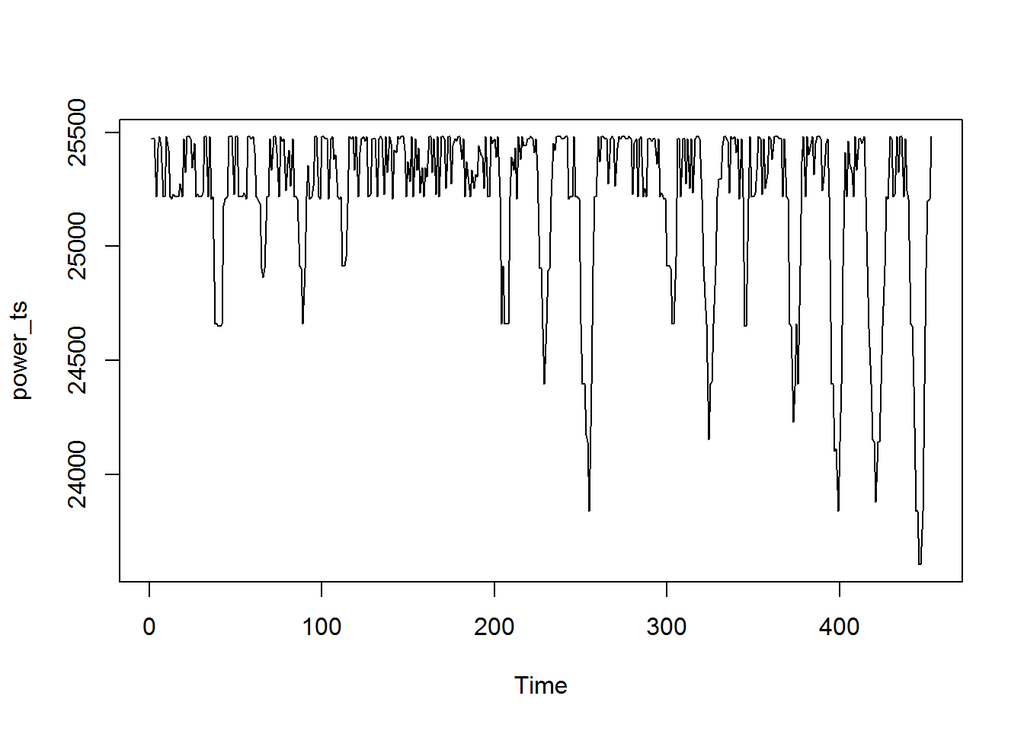

```r
# Constant Variance Violated. Implies non-stationariety

plot(power_ts)
```

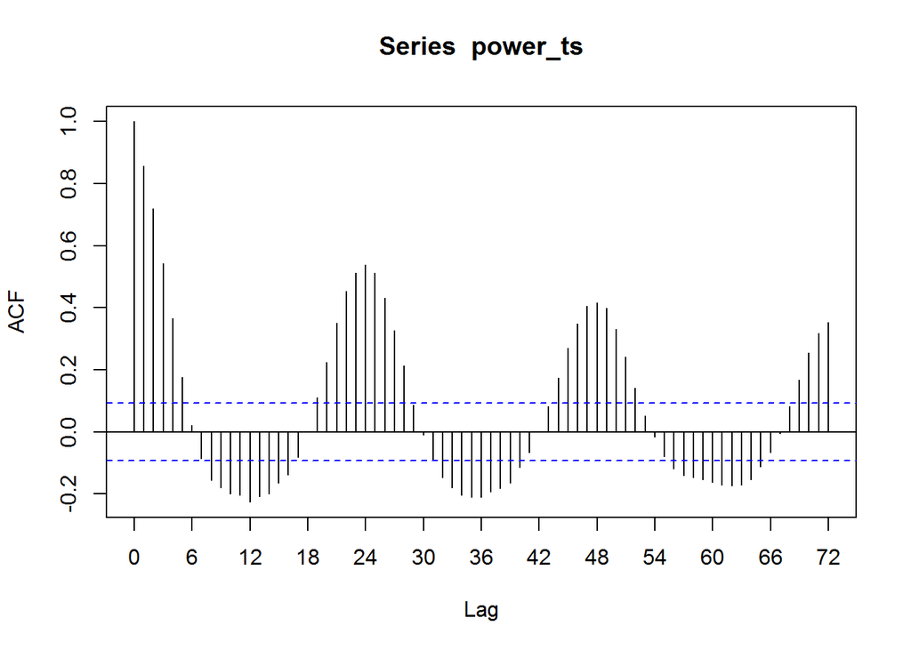

```r
# The ACF for the Raw signal shows seasonality. Supports non-stationariety

acf(power_ts, lag.max = 72,xaxp=c(0,72,12))
```

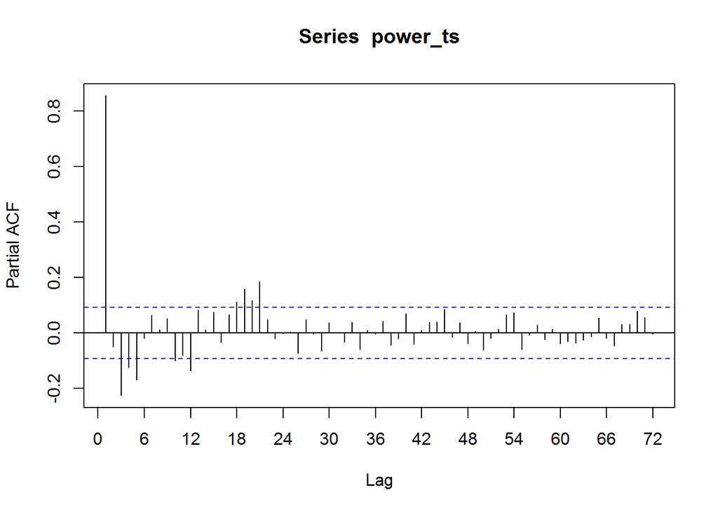

```r
# The PACF is 'hard to interpret'

pacf(power_ts, lag.max = 72,xaxp=c(0,72,12))
```

**Evidence shows data is not stationary. Take difference of the raw data**

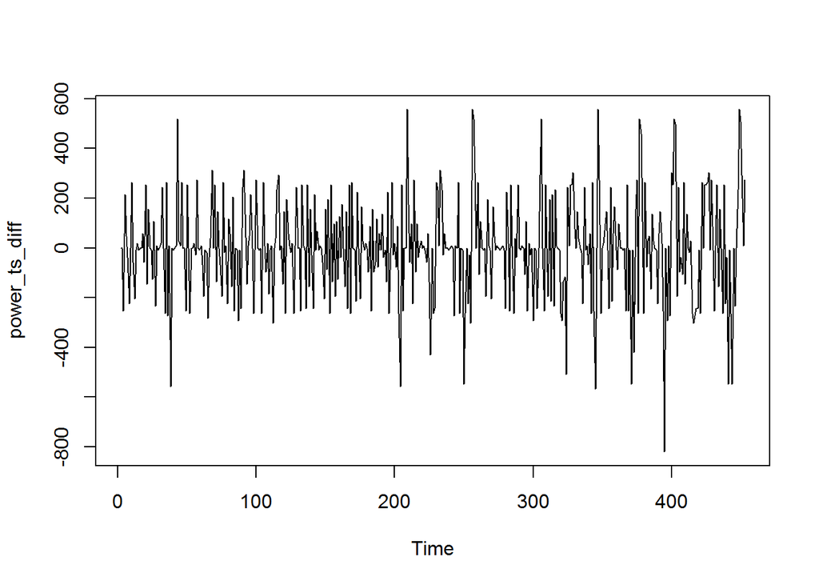

```r
power_ts_diff = diff(power_ts, differences = 1)
plot(power_ts_diff)
```

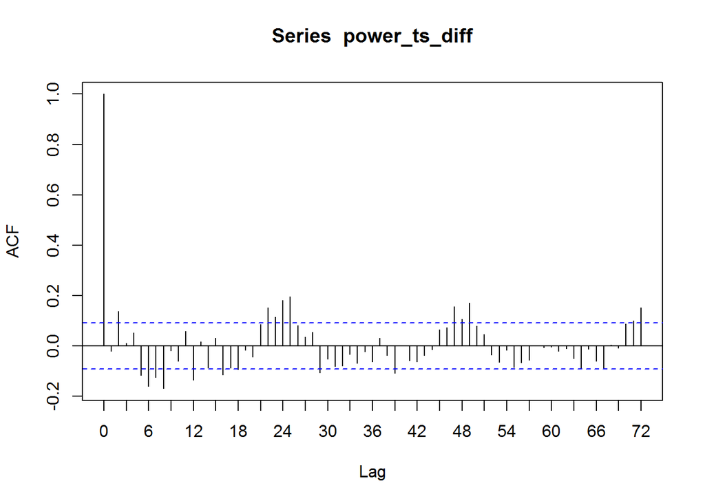

```r
# The ACF for the differenced raw data still shows seasonality. Supports non-stationariety

acf(power_ts_diff, lag.max = 72,xaxp=c(0,72,24))
```

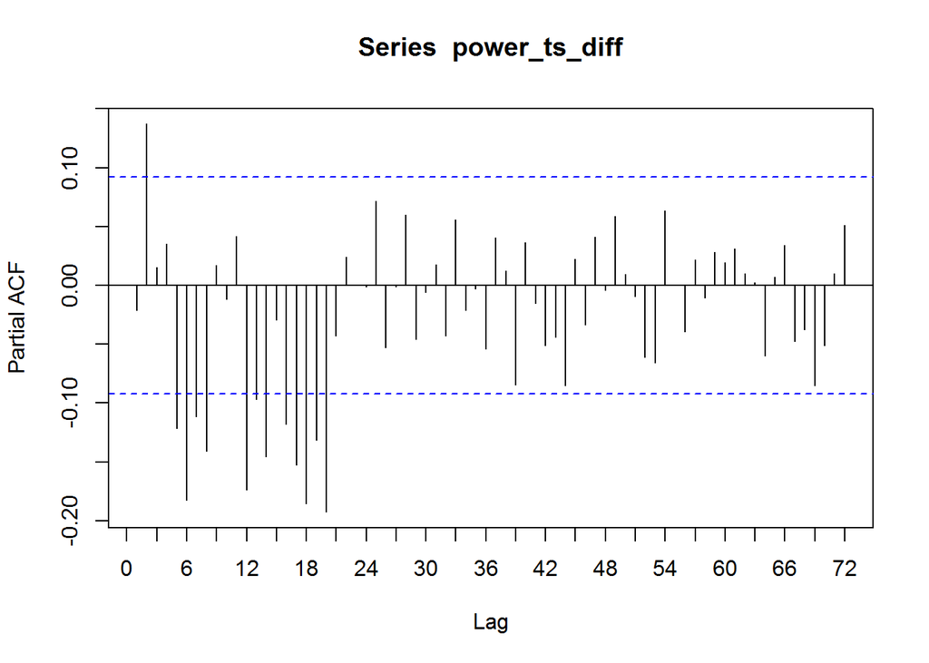

```r
# The PACF for the differenced raw data is 'hard to interpret'

pacf(power_ts_diff, lag.max = 72,xaxp=c(0,72,24))
```

**Some Seasonality still observed. Data is still not stationary. Take Seasonal Difference**

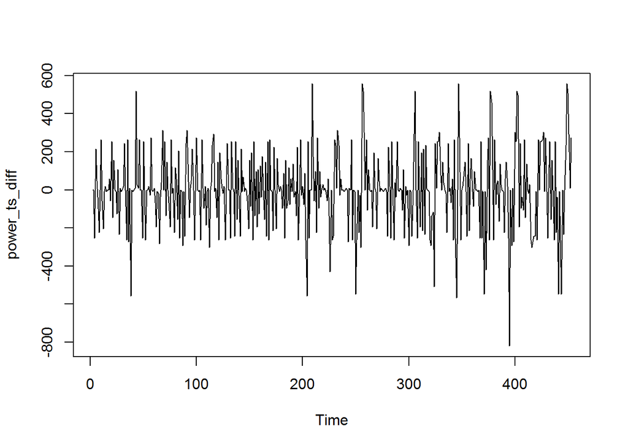

```r
power_ts_diff_sdiff = diff(power_ts_diff, differences = 1,24)

# Before
plot(power_ts_diff)
```

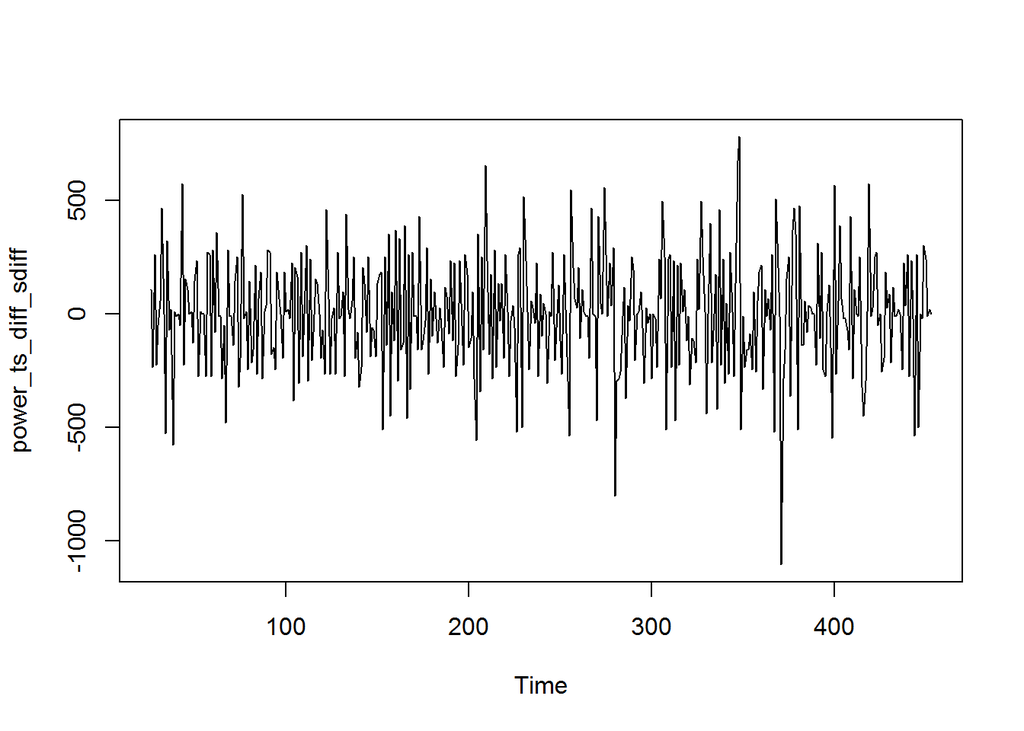

```r
# After
plot(power_ts_diff_sdiff)
```

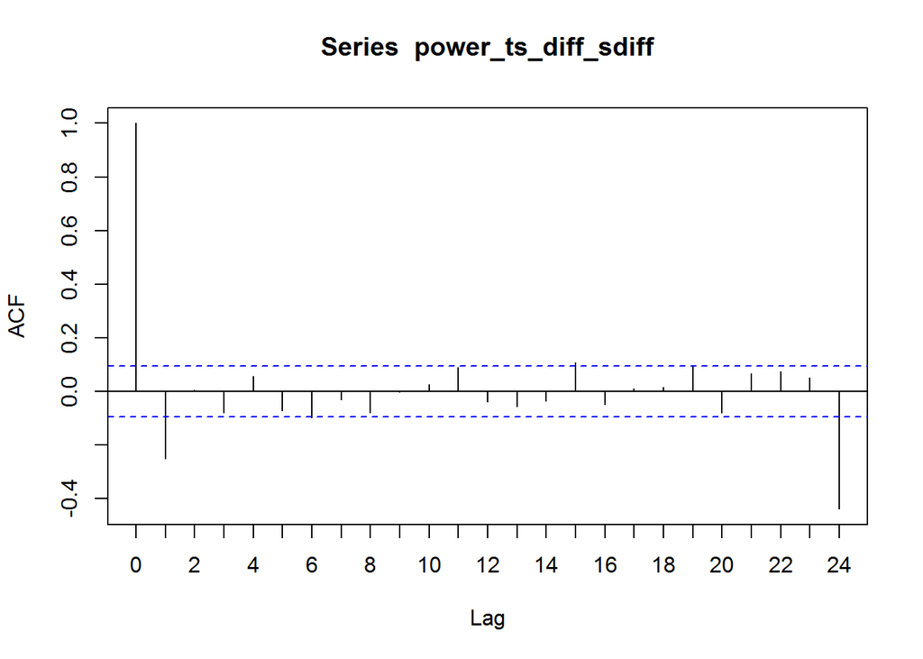

```r
# Seasonal difference of first order seems to achieve stationariety. ACF Observations here

acf(power_ts_diff_sdiff, lag.max = 24,xaxp=c(0,24,24))
```

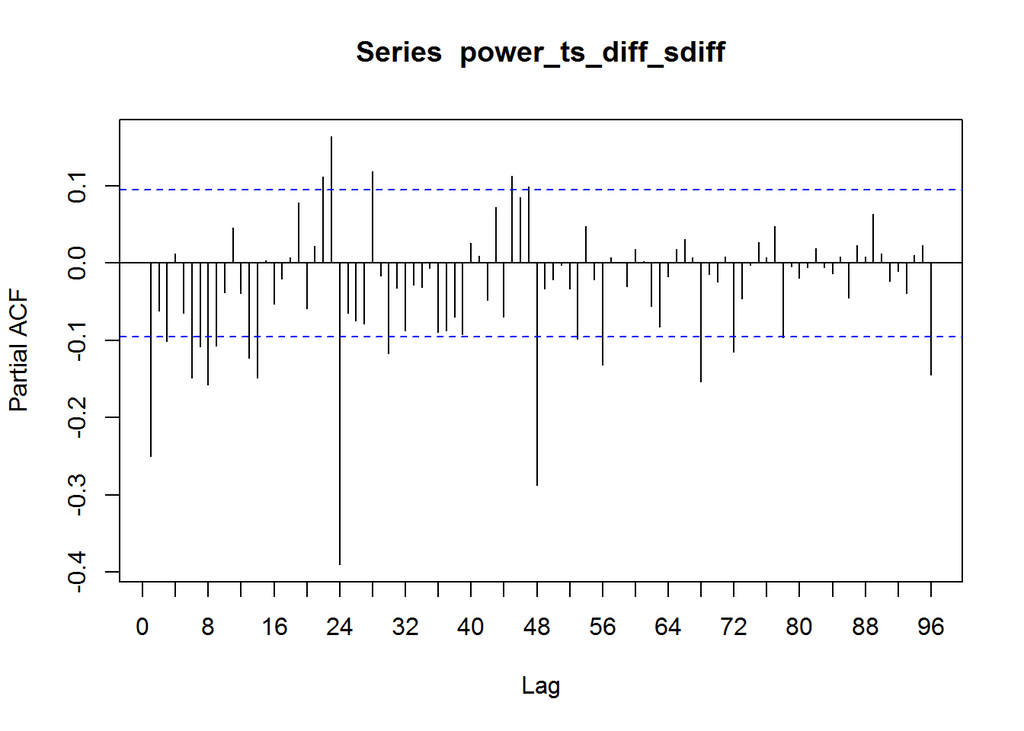

```r
# Seasonal difference of first order seems to achieve stationariety. PACF Observations here

pacf(power_ts_diff_sdiff, lag.max = 96,xaxp=c(0,96,24))
```

The ACF and PACF functions suggest the following model combinations:

- Non-Seasonal Part:
  - AR1 through AR14
  - MA1
- Seasonal Part:
  - AR1 through AR4
  - MA1

**It is important to note that only valid models were considered. Out of the list of valid models, the best model was chosen based on an SBC criteria**

*Once a valid model is chosen the p-values of the estimates can provide further model assessment (parsimony)*

**The model chosen was:**

**ARIMA(5,1,1)(0,1,1)24 based on Lowest SBC model that is valid**

```r
power_ts_arima <- arima(power_ts, order=c(5,1,1), seasonal = list(order = c(0,1,1), period = 24)) # fit an ARIMA(5,1,1)(0,1,1)24 model
```

*Before we forecast we make sure the model is valid*

```r
power_ts_arima_forecasts <- forecast(power_ts_arima, h=6) #where h is the number of data points to forecast

Box.test(power_ts_arima_forecasts$residuals, lag=72, type="Ljung-Box")
```

```
##
##  Box-Ljung test
##
## data:  power_ts_arima_forecasts$residuals
## X-squared = 75.069, df = 72, p-value = 0.3792
```

*Box-Ljung test shows lowest p-value > 0.05, so the lags for each of the residual are not statistically significant*

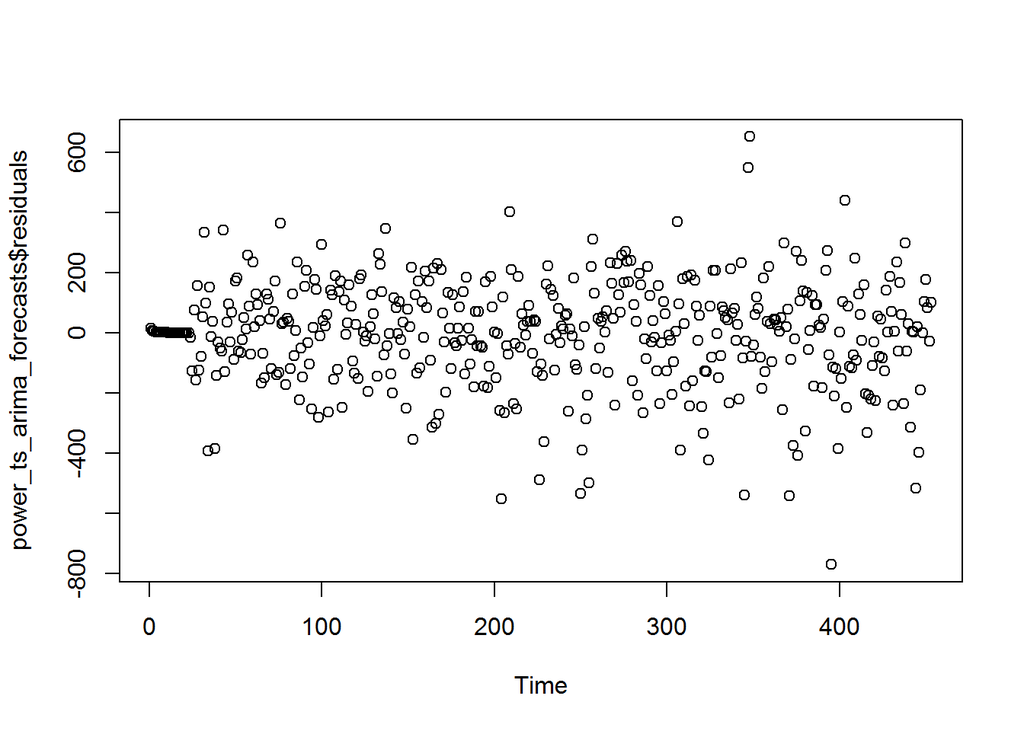

```r
plot(power_ts_arima_forecasts$residuals, type = "p")            # make time plot of forecast errors
```

*Residulas are consistent with white noise. Model is Valid*

*Next, Look at forecast from the valid model*

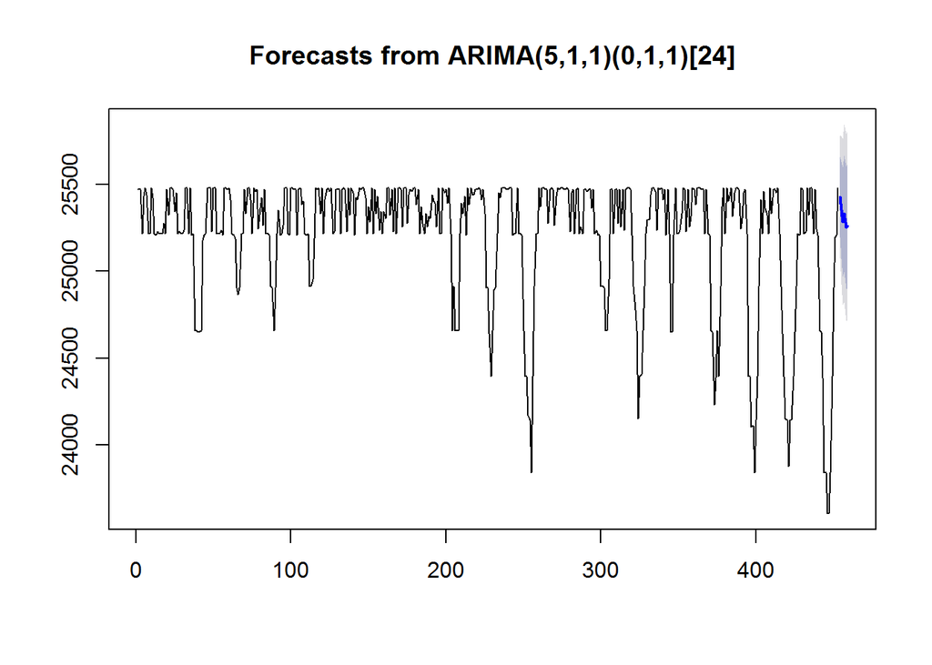

```r
plot(power_ts_arima_forecasts)
```

```r
# Calculate p-values to see if model is parsimonious

coeftest(power_ts_arima)
```

```
##
## z test of coefficients:
##
##       Estimate Std. Error  z value  Pr(>|z|)
## ar1   0.654674   0.049473  13.2330 < 2.2e-16 ***
## ar2   0.164761   0.057206   2.8802  0.003975 **
## ar3  -0.032989   0.057700  -0.5717  0.567500
## ar4   0.040201   0.057365   0.7008  0.483431
## ar5  -0.155991   0.048876  -3.1916  0.001415 **
## ma1  -0.978898   0.014692 -66.6269 < 2.2e-16 ***
## sma1 -0.790193   0.037322 -21.1722 < 2.2e-16 ***
## ---
## Signif. codes:  0 '***' 0.001 '**' 0.01 '*' 0.05 '.' 0.1 ' ' 1
```

*The model is not parsimonious, not all estimates are significant. The model can be improved upon. We will create a gap model using the ‘fixed’ option*

```r
power_ts_arima_gap <- arima(power_ts, order=c(5,1,1), seasonal = list(order = c(0,1,1), period = 24), fixed = c(NA, NA, 0, 0, NA, NA, NA), transform.pars = F)
```

*We need to investigate if the gap model is valid*

```r
power_ts_arima_gap_forecasts <- forecast(power_ts_arima_gap, h=6) #where h is the number of data points to forecast
```

```
## Warning in predict.Arima(object, n.ahead = h): MA part of model is not
## invertible
```

```r
Box.test(power_ts_arima_gap_forecasts$residuals, lag=72, type="Ljung-Box")
```

```
##
##  Box-Ljung test
##
## data:  power_ts_arima_gap_forecasts$residuals
## X-squared = 76.903, df = 72, p-value = 0.3246
```

*Box-Ljung Test of white noise is passes*

*Check the white noise plot*

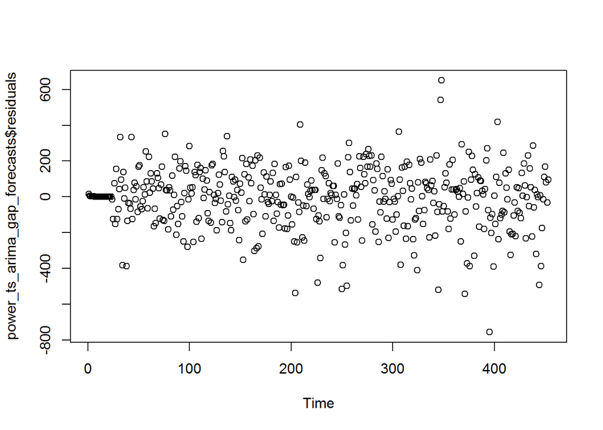

```r
plot(power_ts_arima_gap_forecasts$residuals, type = "p")            # make time plot of forecast errors
```

```r
# Calculate p-values to see if new model is parsimonious

coeftest(power_ts_arima_gap)
```

```
##
## z test of coefficients:
##
##       Estimate Std. Error  z value  Pr(>|z|)
## ar1   0.650728   0.049047  13.2674 < 2.2e-16 ***
## ar2   0.161583   0.050049   3.2285  0.001244 **
## ar5  -0.143532   0.037474  -3.8302  0.000128 ***
## ma1  -1.021782   0.015392 -66.3827 < 2.2e-16 ***
## sma1 -0.790829   0.037094 -21.3196 < 2.2e-16 ***
## ---
## Signif. codes:  0 '***' 0.001 '**' 0.01 '*' 0.05 '.' 0.1 ' ' 1
```

# Prediction on Fitted Data

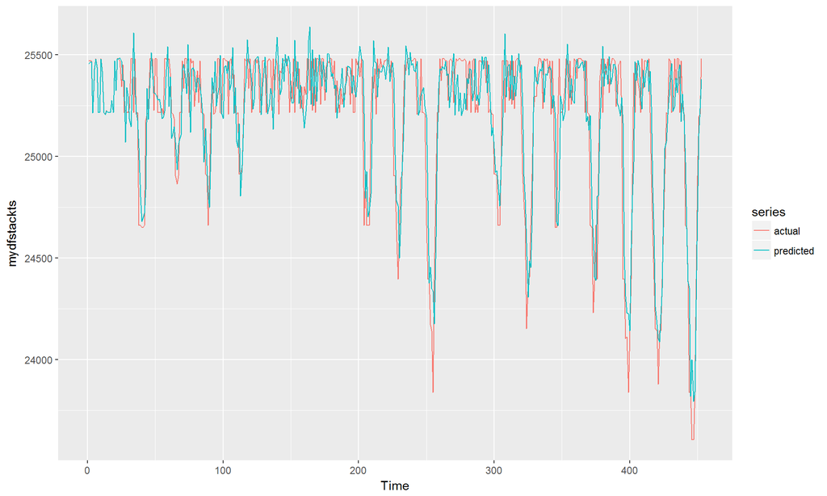

```r
actual = power_ts_arima_forecasts$x
predicted = power_ts_arima_forecasts$fitted

mydfstack = data.frame(actual,predicted)

mydfstackts = ts(mydfstack)

autoplot(mydfstackts, facets = FALSE)
```

# Validation

*Compare against a hold out set*

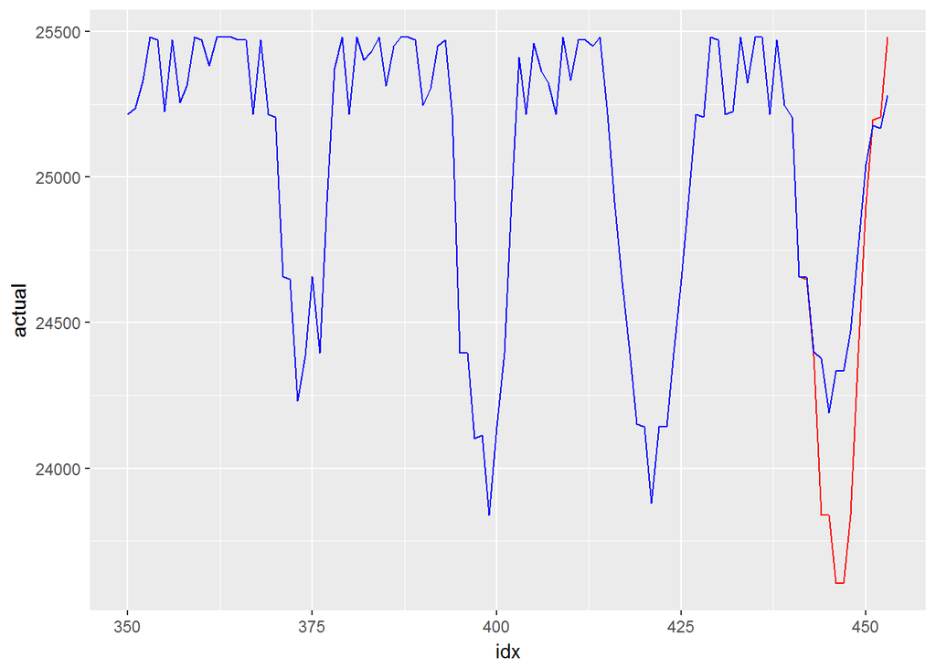

```r
numterms = 12 # Number of terms to hold out and to forecast

df_short = as.data.frame(df[(1:(dim(df)[1]-numterms)),]) # Subset everything but the last 12 terms and use that to build the model

colnames(df_short) <- c("Power")


power_ts_h_out = ts(df_short$Power) # Create a time object for the dataframe subset

power_ts_arima_h_out <- arima(power_ts_h_out, order=c(5,1,1), seasonal = list(order = c(0,1,1), period = 24))

power_ts_arima_forecasts_h_out <- forecast(power_ts_arima_h_out, h=numterms)

forecastedset = as.data.frame(c(power_ts_h_out,power_ts_arima_forecasts_h_out$mean), col.names = c('Forecast'))

forecastedset$idx = seq(1,453,1)

power_ts_raw = ts(df$Power)

mydfstack2 = data.frame(power_ts_raw, forecastedset)

colnames(mydfstack2) = c('actual','predicted','idx')

mydfstack2$idx = seq(1,453,1)

subset = mydfstack2[350:453,]

ggplot(subset, aes(idx)) +
  geom_line(aes(y=actual), colour="red") +
  geom_line(aes(y=predicted), colour="blue")
```

# Future Improvements

- Transfer Function using Ambient Temperature. Hotter Days will result in lower power output.
- Outliers and Level Shifts. Suggested use of tso package.
- Investigate Invertibility Issue. Including outliers and level shift may resolve this issue.

# Resources and Additional Information

https://en.wikipedia.org/wiki/Bayesian_information_criterion

http://a-little-book-of-r-for-time-series.readthedocs.io/en/latest/src/timeseries.html#decomposing-seasonal-data